# ch7_t-distribution.Rmd

Example showing that sampling distribution for the mean of a sample from a normal distribution with an unknown variance is a **t-distribution with n-1 degrees of freedom**.

Consider the sample mean $\bar{X}$ from a sample of size n=15 from $X\sim N(\mu,\sigma^2)$.

Simulate the sampling distribution with $N$ samples. For each sample find the estimates for $\hat{\mu}=\bar{x}$ and $\hat{\sigma}=s$, then show that the normalized variable for the mean of the sampling distribution,
$$W = \frac{\bar{X} - \mu}{s / \sqrt{n}},$$
does not have a normal distribution but a t-distribution.

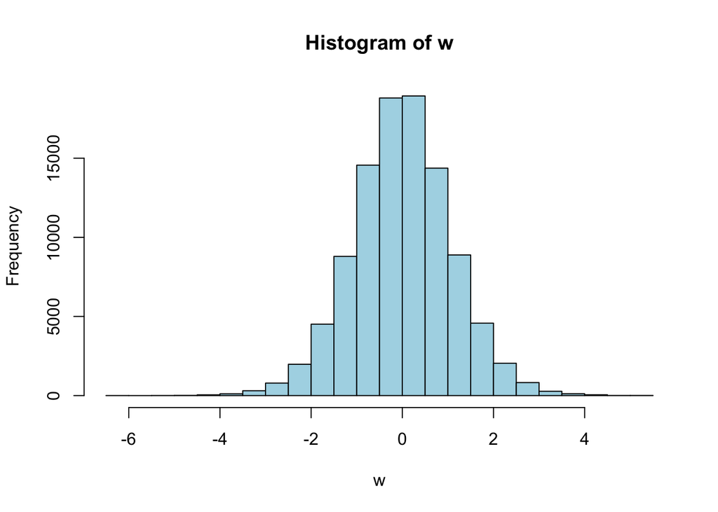

```r
n <- 15
mu <- 25
sigma <- 7
N <- 10**5  # number of samples
w <- numeric(N) # create a vector to hold normalized mean(x) for each sample
# loop to create sample, calculate normalized mean, store it in w array
for (i in seq(1,N)) {
  x <- rnorm(n,mu,sigma)         # sample
  xbar <- mean(x)                # mean
  s <- sd(x)                     # std dev
  w[i] <- (xbar-mu)/(s/sqrt(n))  # normalized mean saved in w[i]
}
hist(w,col="lightblue")
```

Check if the distribution of $W$ is normal using a qqplot:

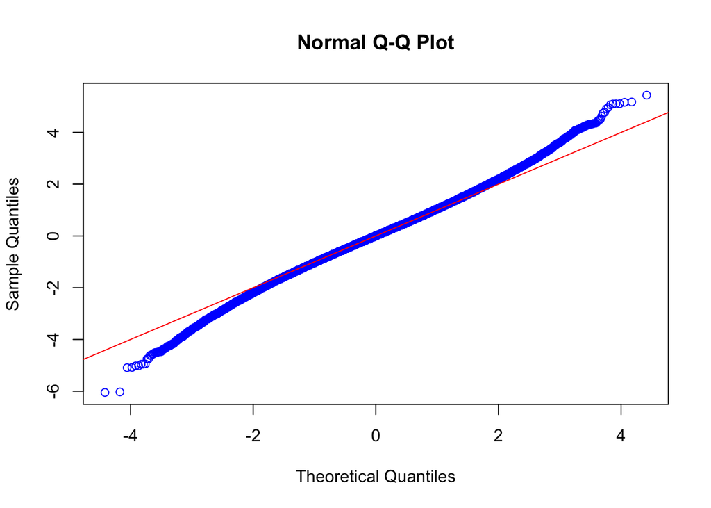

```r
qqnorm(w,col="blue")  # qqplot of w vs std normal
abline(0,1,col="red")    # line with intercept=0 and slope=1
```

The qqplot shows that $W$ is not normal; the sample quantiles have more extreme values in the tails of the distribution relative to the theoretical quantiles which means $W$ has longer tails than a normal distribution.

Claim $W \sim t(n-1)$, a t-distribution with n-1 degrees of freedom.

**t-distribution** (also known as “Student’s t-distribution”) = $t(k)$ where $k$ is a parameter called the degrees of freedom (also “dof” or “df”).

In R, the t-distribution is just “t” so the pdf is given by “dt(x,df=k)” (see below).

Plot pdf of std normal and t-distribution for different dof

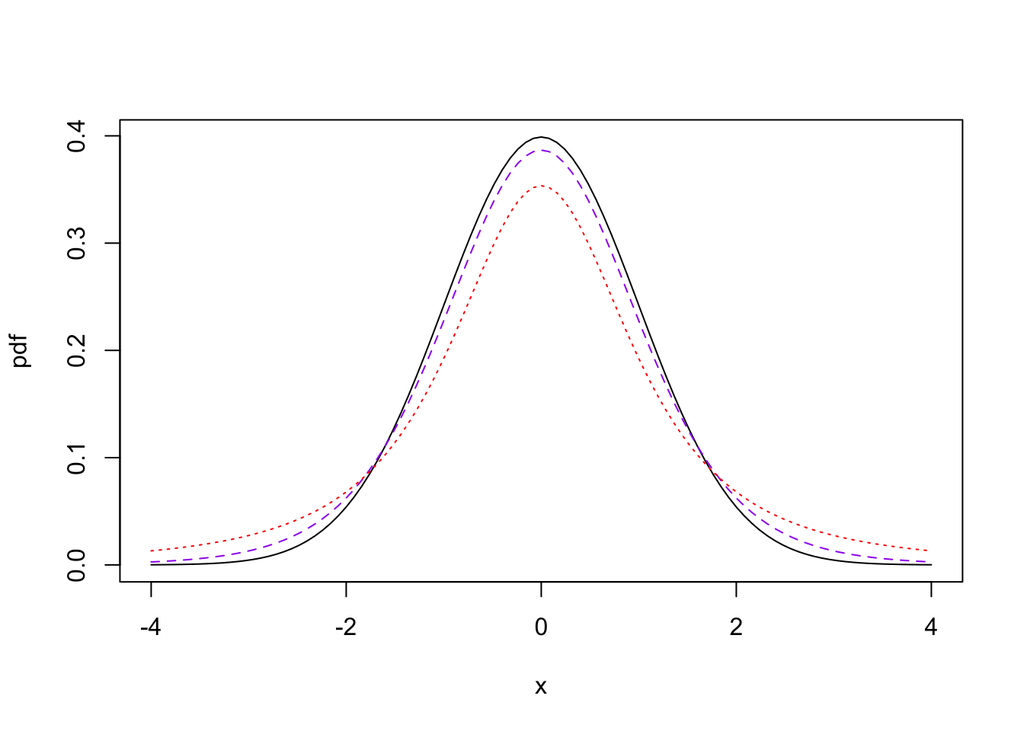

```r
xfine<-seq(-4,4,length=101)       # x array for plotting
plot(xfine,dnorm(xfine),type='l',xlab='x',ylab='pdf')   # std normal
lines(xfine,dt(xfine,df=8),lt='dashed',col='purple')    # t(df=8)
lines(xfine,dt(xfine,df=2),lt='dotted',col='red')       # t(df=2)
```

Shown above are plots of the pdfs of std normal (solid) and the t-distribution (dashed is df=8, dotted is df=2).  
- The t-distribution has similar shape to normal distribution but shorter peak and longer tails.  
- As df -> $\infty$ the t-distribution converges to the standard normal distribution.

Make a qqplot of W vs t(n-1)

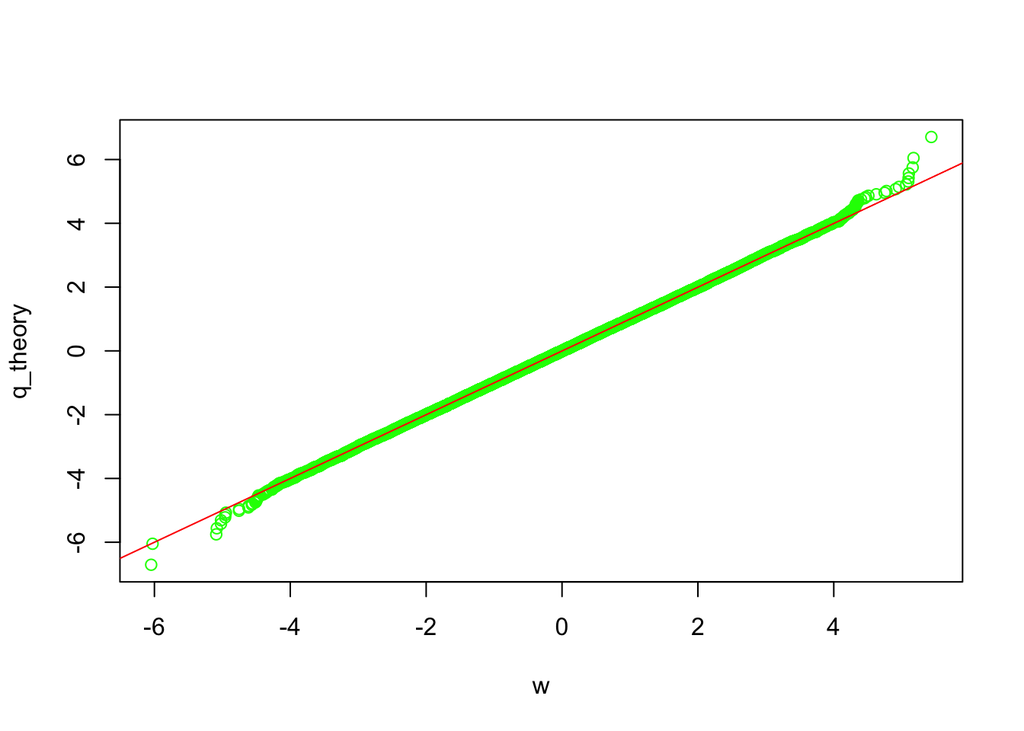

```r
pfine<-(seq(1:N)-0.5)/N # array of size N, evenly spaced in (0,1)
q_theory <- qt(pfine,n-1)  # t(n-1) quantiles
qqplot(w,q_theory,col="green")
abline(0,1,col="red") # line with intercept=0 and slope=1
```

Here, the agreement in the qqplot is excellent, confirming $W \sim t(n-1)$.

More details of t-distribution are in Appendix B.11 (also includes the proof of $W \sim t[n-1]$).